# Ar Sullivan Santana Najera

**DATA ANALYST | STATISTICAL ANALYSIS | PYTHON | R | SQL | BUSINESS INTELLIGENCE**

📍 Aguascalientes, México

📧 sullivan.santana@gmail.com

📱 +52 449 919 6772

🌐 **[LinkedIn](https://www.linkedin.com/in/ar-sullivan-santana-najera-758a14ab/)**

🔗 **[GitHub](https://github.com/sullivansantana)**

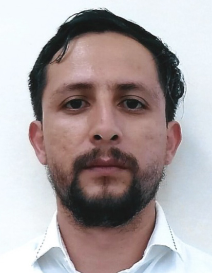

# Professional Summary

Data Analyst and Industrial Engineer with more than **10 years of professional experience** analyzing operational data, generating statistical indicators, developing dashboards, forecasting demand, and supporting decision-making through data-driven solutions.

Experienced in **Python, R, SQL, Excel and Power BI**, with strong knowledge of database management, data cleaning, exploratory data analysis, statistical modeling, time series forecasting, and KPI reporting.

Currently pursuing a **Master’s Degree in Data Science**, applying statistical and machine learning techniques to forecasting, business intelligence, operational analytics, and predictive modeling.

# Professional Experience

## Data Analyst – IT Metrics Team | Softtek

**October 2024 – Present**

### Key Achievements

- Processed and analyzed operational datasets using Python, SQL and Excel.
- Developed forecasting models using Prophet, ARIMA, Holt-Winters and XGBoost.
- Created Power BI dashboards for operational monitoring and KPI analysis.
- Automated reporting processes using Python.
- Applied anomaly detection techniques to identify operational deviations.
- Produced statistical reports supporting business decision-making.

## Process Quality Leader | Softtek

**August 2019 – September 2024**

### Key Achievements

- Generated operational indicators and statistical reports for executive management.
- Processed large operational datasets supporting continuous improvement initiatives.
- Developed forecasting models for demand planning and workload estimation.
- Built Power BI dashboards for monitoring KPIs and business performance.
- Performed data quality analysis and reporting validation.
- Automated data extraction and reporting using Python.
- Collaborated with multidisciplinary teams to improve data quality and analytical reporting.

## Quality Analyst Compliance | Softtek

### Key Achievements

- Developed Power BI dashboards for operational reporting.
- Managed databases supporting compliance and operational analysis.
- Generated analytical reports for management decision-making.
- Conducted data validation and quality reviews.
- Collaborated with international teams across Mexico, USA, Spain, India and Colombia.

# Featured Projects

## NLP Author Attribution in Political Discourse

**Master’s Thesis • INFOTEC • 2026**

### Project Summary

Engineered a large-scale NLP system for author attribution, processing **928K tweets** from 47 Mexican politicians. Achieved **63.5% accuracy** and **60% macro F1-score** using contextual embeddings from a fine-tuned BERT model, establishing a robust baseline for multi-class authorship identification in Spanish political discourse.

### Tech Stack

`PyTorch` • `Transformers` • `TensorFlow/Keras` • `Scikit-learn` • `UMAP` • `NumPy/Pandas` • `CUDA`

### Impact

First large-scale author attribution study for Mexican political Twitter, providing insights into ideological vs. stylistic linguistic markers and creating a reproducible pipeline for political discourse analysis in Spanish.

# Technical Skills

**Statistical Analysis** Statistical Analysis • Exploratory Data Analysis (EDA) • Data Cleaning • Data Validation • Statistical Reporting • Time Series Analysis • Forecasting • KPI Development

**Business Intelligence & Governance**  
Business Intelligence • KPI Reporting • Data Modeling • Risk Analytics • Governance • Business Controls • Compliance Reporting • Internal Controls • Audit Readiness • Forecasting

**Programming & Analytics**  
Python • SQL • SQLite • R • Pandas • NumPy • Scikit-learn • XGBoost • Prophet • PyTorch • TensorFlow

**Visualization**  
Power BI • Tableau • Plotly • Matplotlib • ggplot2 • Highcharts

**Business Tools**  
Microsoft Excel (Advanced) • Power Query • PowerPoint

# Education

## INFOTEC

**Master’s Degree in Data Science and Information** *(Currently Enrolled) [Credential](https://posgrados.infotec.mx/alumnado/estatus/credencial/23A4553A18)*

## Tecnológico Nacional de México

**Bachelor’s Degree in Industrial Engineering**

# Certifications

**Kaggle**

- Kaggle – [Intro to SQL](https://www.kaggle.com/learn/certification/sullivansantana/intro-to-sql)
- Kaggle – [Intro to Machine Learning](https://www.kaggle.com/learn/certification/sullivansantana/intro-to-machine-learning)
- Kaggle – [Intermediate Machine Learning](https://www.kaggle.com/learn/certification/sullivansantana/intermediate-machine-learning)
- Kaggle – [Pandas](https://www.kaggle.com/learn/certification/sullivansantana/pandas)
- Kaggle – [Data Visualization](https://www.kaggle.com/learn/certification/sullivansantana/data-visualization)
- Kaggle – [Time Series](https://www.kaggle.com/learn/certification/sullivansantana/time-series)
- Kaggle – [Data Cleaning](https://www.kaggle.com/learn/certification/sullivansantana/data-cleaning)
- Kaggle – [Feature Engineering](https://www.kaggle.com/learn/certification/sullivansantana/feature-engineering)

**Additional Certifications**

- Udemy - [Mathematics and Statistics for Machine Learning](https://drive.google.com/file/d/1VgaVbIg4rOH8ptDPooVC2swY2bMbf0LZ/view?usp=drive_link)
- Simplilearn - [Data Science with Python](https://drive.google.com/file/d/1M1BJ6F5_VIwBEke5n3Pp1sgA9CbgwwSM/view?usp=drive_link)
- Simplilearn - [Data Science with R](https://drive.google.com/file/d/1UdpRko9IkazSxVNfvpybxREqZgsJ2i6F/view?usp=drive_link)
- Softtek - [Interpretation of the Standard & Internal Auditor for ISO/IEC 20000](https://drive.google.com/file/d/1eGA9w049OfQf19AkM3AZcGlBdGHK36fs/view?usp=sharing)
- Axelos - [ITIL v3 Foundation Certification](https://drive.google.com/file/d/1TxGEKLxgRTsNRZXsnFTOfN2lPx88tdFJ/view?usp=drive_link)

# Languages

- Spanish — Native
- English — Intermediate (B1)

# Portfolio

**[Tableau Public](https://public.tableau.com/app/profile/ar.sullivan.santana)**

**[Data Science Portfolio](https://www.datascienceportfol.io/sullivansantana)**